# Economic Analysis of Trump’s Second Term: Domestic and Global Impacts

Seungheon Yeo, Chanhyong Lee

2024-12-12

# Executive summary

1. International Analysis: The study will analyze macroeconomic variables affected during the 2016 Trump and 2020 Biden elections to anticipate potential changes in global economic conditions if Trump is re-elected in 2024. The analysis will also consider the ongoing confrontation between the West, led by the US, and BRICS countries, with China and Russia as central players. BRICS countries, comprising developing and emerging economies, argue for alternatives to the current Western-dominated trade system (e.g., WTO) due to perceived inequalities. Investigating the opposing trends between the US-led West and BRICS will offer insights into shifting global dynamics.
2. domestic Analysis: This analysis evaluates the impact of major U.S. presidential elections on South Korea’s stock market, focusing on industry-specific performance during the 2016 Trump election, the 2020 Biden election, and projecting potential outcomes for the 2024 Trump re-election. Using data from the Korea Exchange (KRX), the study calculates the average stock price change rates for key industries during pre- and post-election periods. The study highlights the profound connection between U.S. presidential election outcomes and South Korea’s industrial performance, emphasizing the need for stakeholders to anticipate policy-driven market changes. Statistical methods and visualizations provide robust insights into these dynamics, offering a foundation for strategic decision-making.

# Data background

1. International Analysis: I used exchange rate data from the economic data released by the U.S. Federal Reserve. Specifically, I utilized the Euro, Brazil, India, China, and South Africa Exchange to U.S. Dollar Spot statistics. For stock data, I used Yahoo Finance (Stock.price), including data for Europe’s FTSE, as well as for Brazil, India, and China.
2. domestic Analysis: I utilizes industry-level and stock-level data from the Korea Exchange (KRX) to analyze the impact of U.S. presidential elections on South Korea’s stock market. The data includes stock price information and industry classifications, allowing for detailed analysis of pre- and post-election trends.

# Data cleaning

1. International Analysis: Using the tidyquant package, I extracted data from the U.S. Federal Reserve’s data portal and Yahoo Finance through functions. I also retrieved data for specific time points using built-in functions. However, due to weekends, public holidays, or country-specific factors, some missing values existed in the dataset, which were subsequently removed.
2. domestic Analysis: The data cleaning process involved importing stock performance and industry classification data, addressing missing values, and ensuring consistency across datasets. Missing critical fields like 종목코드 or 업종명 were excluded, while non-critical missing values were handled during calculations. Data types were standardized for analysis, and outliers were assessed for validity, with erroneous values removed. Period indicators (Pre_Election, Post_Election) were added based on election day and data was merged to associate stock performance with industry categories. The cleaned data was aggregated by industry and period to calculate average stock price changes, with missing values excluded from calculations. Finally, the results were validated to ensure completeness and accuracy for robust analysis and visualization.

# Individual figures

## Figure 1: Euro Exchange Trends

I first examined fluctuations in Europe, representing the Western bloc. The goal was to identify trends and understand how changes in U.S. administrations influence the Western side.

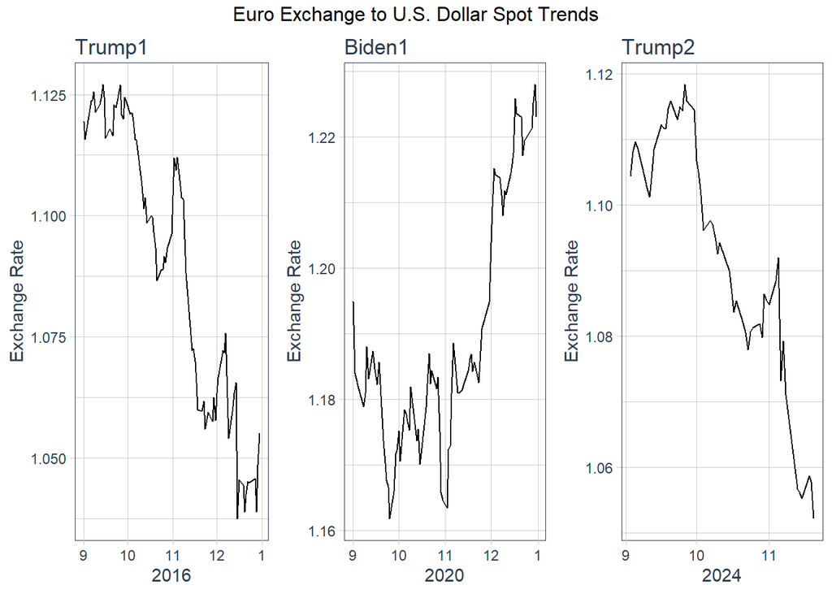

```r
library(tidyquant)
library(ggplot2)
library(tidyverse)

# Get the economic data for euro
euro <- tq_get('DEXUSEU', get = 'economic.data', from = '2016-01-01', to = '2024-11-20')


# Remove rows with missing values
euro <- euro %>% drop_na()

# Ensure the date column is in Date format
euro <- euro %>% mutate(date = as.Date(date))

# Separate the data into individual periods
period_2016 <- euro %>% filter(date >= as.Date('2016-09-01') & date <= as.Date('2016-12-31'))
period_2020 <- euro %>% filter(date >= as.Date('2020-09-01') & date <= as.Date('2020-12-31'))
period_2024 <- euro %>% filter(date >= as.Date('2024-09-01') & date <= as.Date('2024-11-20'))

# Plot the data for each period
p1 <- ggplot(period_2016, aes(x = date, y = price)) +
  geom_line() +
  theme_tq() +
  labs(title = "Trump1", x = "2016", y = "Exchange Rate")

p2 <- ggplot(period_2020, aes(x = date, y = price)) +
  geom_line() +
  theme_tq() +
  labs(title = "Biden1", x = "2020", y = "Exchange Rate")

p3 <- ggplot(period_2024, aes(x = date, y = price)) +
  geom_line() +
  theme_tq() +
  labs(title = "Trump2", x = "2024", y = "Exchange Rate")

# Display the plots in a grid
library(gridExtra)
plot1 <- grid.arrange(p1, p2, p3, ncol = 3, top = "Euro Exchange to U.S. Dollar Spot Trends")
```

## Figure 2: Euro Exchange rate comparison

However, it is unclear whether these fluctuations reflect a broader macroeconomic trend or are specific to U.S. election periods. To investigate this, I examined the volatility during specific U.S. election periods compared to the overall annual volatility. If volatility is significantly higher only during election periods, a correlation could be established to some extent. However, the impact of COVID-19 in 2020 cannot be ignored.

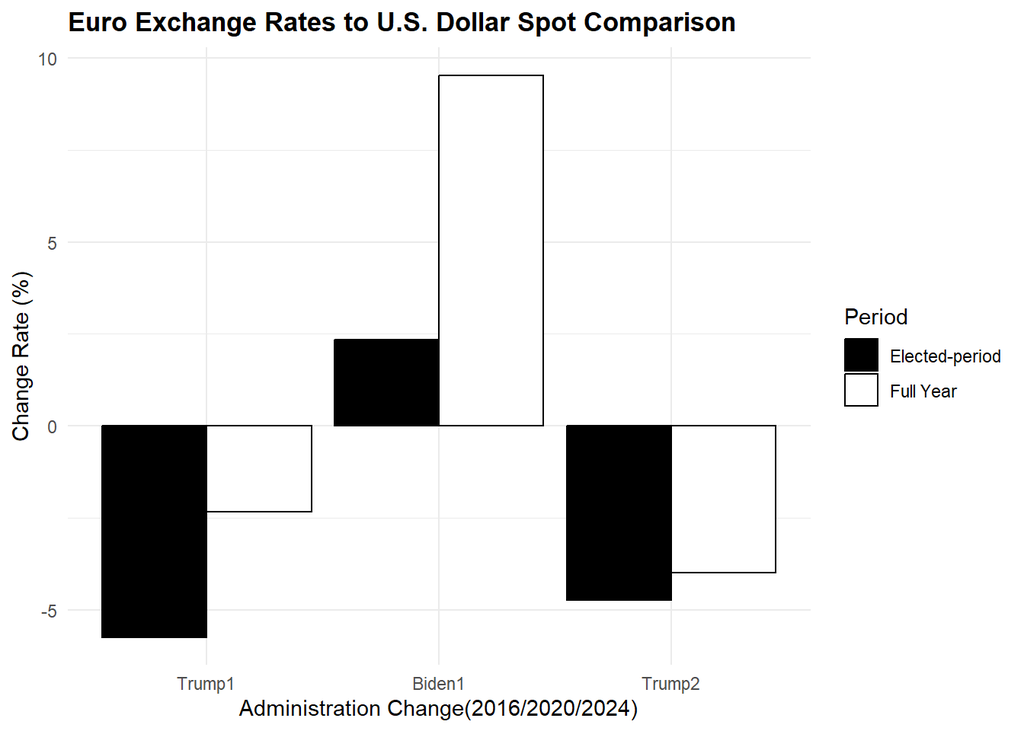

```r
# Calculate change rates for the entire year and specific periods
calculate_change_rate <- function(data, start_date, end_date) {
  period_data <- data %>% filter(date >= as.Date(start_date) & date <= as.Date(end_date))
  change_rate <- (last(period_data$price) - first(period_data$price)) / first(period_data$price) * 100
  return(change_rate)
}

# Change rates for 2016
rate_2016_full <- calculate_change_rate(euro, '2016-01-01', '2016-12-31')
rate_2016_period <- calculate_change_rate(euro, '2016-09-01', '2016-12-31')

# Change rates for 2020
rate_2020_full <- calculate_change_rate(euro, '2020-01-01', '2020-12-31')
rate_2020_period <- calculate_change_rate(euro, '2020-09-01', '2020-12-31')

# Change rates for 2016
rate_2016_full <- calculate_change_rate(euro, '2016-01-01', '2016-12-31')
rate_2016_period <- calculate_change_rate(euro, '2016-09-01', '2016-12-31')

# Change rates for 2020
rate_2020_full <- calculate_change_rate(euro, '2020-01-01', '2020-12-31')
rate_2020_period <- calculate_change_rate(euro, '2020-09-01', '2020-12-31')

# Change rates for 2024
rate_2024_full <- calculate_change_rate(euro, '2024-01-01', '2024-11-20')
rate_2024_period <- calculate_change_rate(euro, '2024-09-01', '2024-11-20')

# Create a data frame for visualization
rate_data <- data.frame(
  Year = factor(c("Trump1", "Trump1", "Biden1", "Biden1", "Trump2", "Trump2"), levels = c("Trump1", "Biden1", "Trump2")),
  Period = c("Full Year", "Elected-period", "Full Year", "Elected-period", "Full Year", "Elected-period"),
  ChangeRate = c(rate_2016_full, rate_2016_period, rate_2020_full, rate_2020_period, rate_2024_full, rate_2024_period)
)

# Plot the change rates with black and white style
plot2 <- ggplot(rate_data, aes(x = Year, y = ChangeRate, fill = Period)) +
  geom_bar(stat = "identity", position = "dodge", color = "black") +
  scale_fill_manual(values = c("black", "white")) +
  theme_minimal() +
  theme(plot.title = element_text(face = "bold")) +
  labs(title = "Euro Exchange Rates to U.S. Dollar Spot Comparison", x = "Administration Change(2016/2020/2024)", y = "Change Rate (%)", fill = "Period")

# Display the plot
plot2
```

## Figure 3: Euro Stock Trends

Exchange rates can reflect a country’s monetary and fiscal policies, indicating the influence of government policies. In contrast, stock market fluctuations serve as indicators of market and economic conditions. Therefore, similar to analyzing exchange rate trends, I aimed to examine how changes in U.S. administrations impact the stock market.

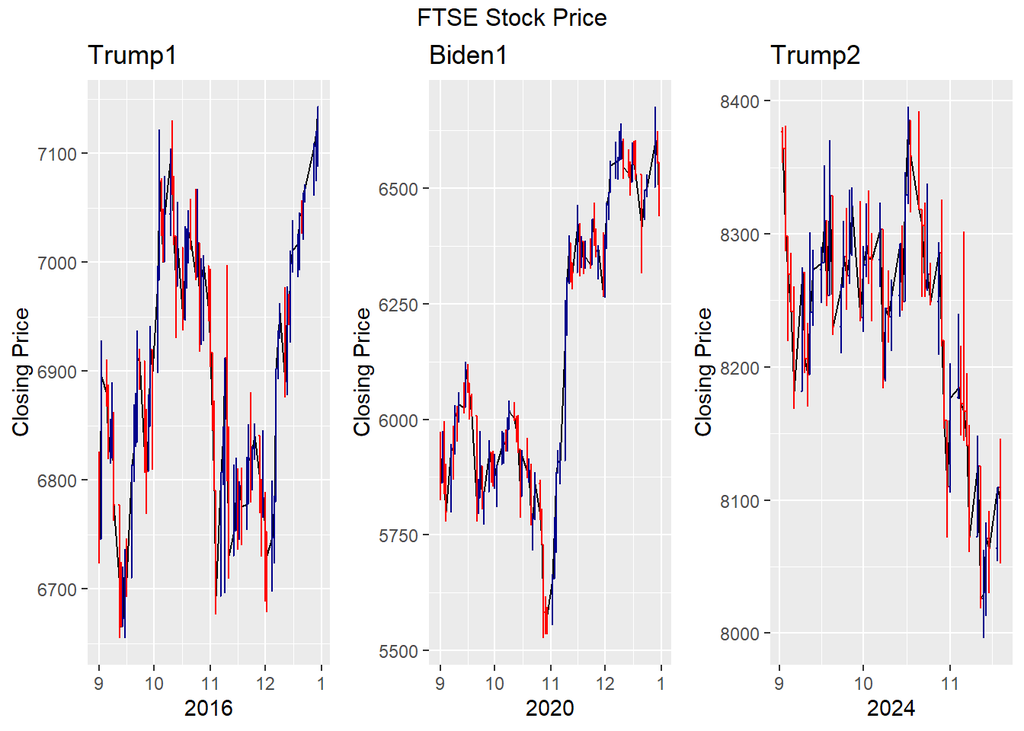

```r
euro_index <- tq_get('^FTSE', get = 'stock.prices', from = '2016-01-01', to = '2024-11-20')

# Ensure the date column is in Date format
euro_index <- euro_index %>% mutate(date = as.Date(date))

# Remove rows with missing values
euro_index <- euro_index %>% drop_na()

# Filter the data for specific periods
period_2016 <- euro_index %>% filter(date >= as.Date('2016-09-01') & date <= as.Date('2016-12-31'))
period_2020 <- euro_index %>% filter(date >= as.Date('2020-09-01') & date <= as.Date('2020-12-31'))
period_2024 <- euro_index %>% filter(date >= as.Date('2024-09-01') & date <= as.Date('2024-11-20'))

# Plot the data for each period
p1 <- ggplot(period_2016, aes(x = date, y = close)) +
  geom_line() +
  geom_barchart(aes(open = open, high = high, low = low, close = close)) +
  labs(title = "Trump1", x = "2016", y = "Closing Price")

p2 <- ggplot(period_2020, aes(x = date, y = close)) +
  geom_line() +
  geom_barchart(aes(open = open, high = high, low = low, close = close)) +
  labs(title = "Biden1", x = "2020", y = "Closing Price")

p3 <- ggplot(period_2024, aes(x = date, y = close)) +
  geom_line() +
  geom_barchart(aes(open = open, high = high, low = low, close = close)) +
  labs(title = "Trump2", x = "2024", y = "Closing Price")

# Display the plots in a grid
library(gridExtra)
plot3 <- grid.arrange(p1, p2, p3, ncol = 3, top = "FTSE Stock Price")
```

## Figure 4: Euro Stock Change Rate Comparison

Similarly, I visualized the data to determine whether volatility was particularly high only during U.S. election periods. Notably, differences between 2020 and 2024 stood out. However, due to the irregular nature of these fluctuations, proving the uniqueness of election periods appears challenging.

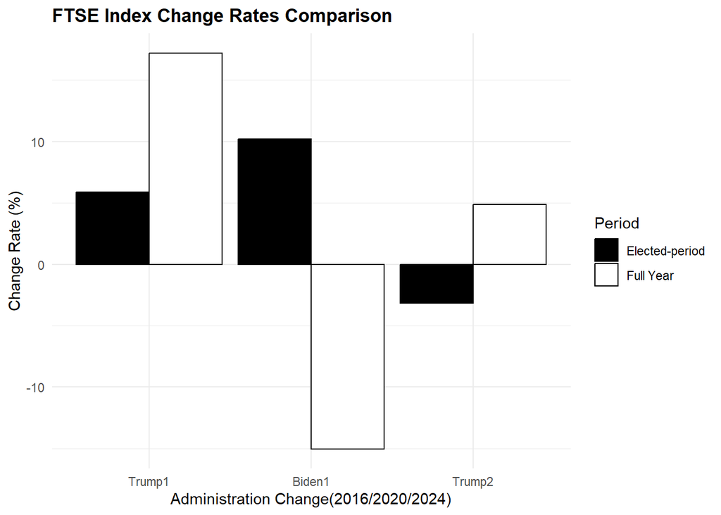

```r
# Calculate change rates for the entire year and specific periods
calculate_change_rate <- function(data, start_date, end_date) {
  period_data <- data %>% filter(date >= as.Date(start_date) & date <= as.Date(end_date))
  change_rate <- (last(period_data$close) - first(period_data$close)) / first(period_data$close) * 100
  return(change_rate)
}

# Change rates for 2016
rate_2016_full <- calculate_change_rate(euro_index, '2016-01-01', '2016-12-31')
rate_2016_period <- calculate_change_rate(euro_index, '2016-09-01', '2016-12-31')

# Change rates for 2020
rate_2020_full <- calculate_change_rate(euro_index, '2020-01-01', '2020-12-31')
rate_2020_period <- calculate_change_rate(euro_index, '2020-09-01', '2020-12-31')

# Change rates for 2024
rate_2024_full <- calculate_change_rate(euro_index, '2024-01-01', '2024-11-20')
rate_2024_period <- calculate_change_rate(euro_index, '2024-09-01', '2024-11-20')

# Create a data frame for visualization
rate_data <- data.frame(
  Year = factor(c("Trump1", "Trump1", "Biden1", "Biden1", "Trump2", "Trump2"), levels = c("Trump1", "Biden1", "Trump2")),
  Period = c("Full Year", "Elected-period", "Full Year", "Elected-period", "Full Year", "Elected-period"),
  ChangeRate = c(rate_2016_full, rate_2016_period, rate_2020_full, rate_2020_period, rate_2024_full, rate_2024_period)
)

# Plot the change rates with black and white style
plot4 <- ggplot(rate_data, aes(x = Year, y = ChangeRate, fill = Period)) +
  geom_bar(stat = "identity", position = "dodge", color = "black") +
  scale_fill_manual(values = c("black", "white")) +
  theme_minimal() +
  theme(plot.title = element_text(face = "bold")) +
  labs(title = "FTSE Index Change Rates Comparison", x = "Administration Change(2016/2020/2024)", y = "Change Rate (%)", fill = "Period")

# Display the plot
plot4
```

## Figure 5: BICS Exchange Trends

Since Russia is not included in the Federal Reserve’s data portal for BRICS countries and its long-term war makes trend analysis difficult, I decided to focus only on BICS (Brazil, India, China, and South Africa). Similarly, significant volatility was observed in November, coinciding with U.S. election periods.

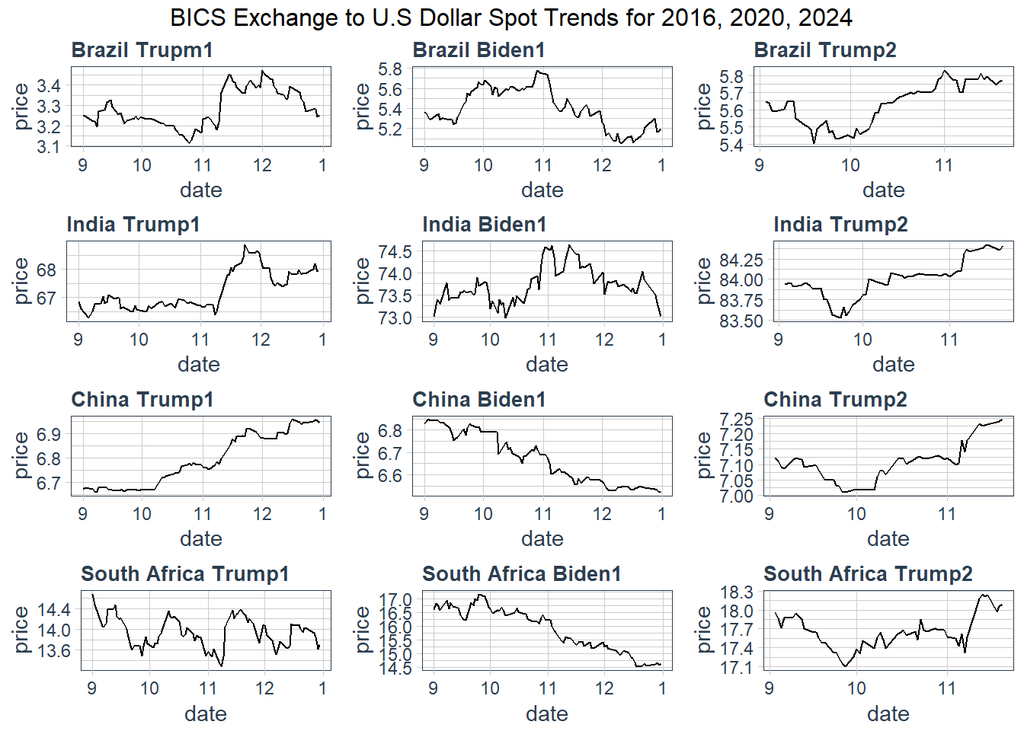

```r
library(tidyquant)
library(ggplot2)

# Get data for the selected countries
brazil <- tq_get('DEXBZUS', get = 'economic.data', from = '2016-01-01', to = '2024-11-20')
india <- tq_get('DEXINUS', get = 'economic.data', from = '2016-01-01', to = '2024-11-20')
china <- tq_get('DEXCHUS', get = 'economic.data', from = '2016-01-01', to = '2024-11-20')
south_africa <- tq_get('DEXSFUS', get = 'economic.data', from = '2016-01-01', to = '2024-11-20')

# Ensure the date column is in Date format for all datasets and remove missing values
brazil <- brazil %>% mutate(date = as.Date(date)) %>% drop_na()
india <- india %>% mutate(date = as.Date(date)) %>% drop_na()
china <- china %>% mutate(date = as.Date(date)) %>% drop_na()
south_africa <- south_africa %>% mutate(date = as.Date(date)) %>% drop_na()

# Filter the data for specific periods for each country
filter_periods <- function(data, start_date, end_date) {
  data %>% filter(date >= as.Date(start_date) & date <= as.Date(end_date))
}

# Create filtered data for each country and period
brazil_2016 <- filter_periods(brazil, '2016-09-01', '2016-12-31')
brazil_2020 <- filter_periods(brazil, '2020-09-01', '2020-12-31')
brazil_2024 <- filter_periods(brazil, '2024-09-01', '2024-11-20')

india_2016 <- filter_periods(india, '2016-09-01', '2016-12-31')
india_2020 <- filter_periods(india, '2020-09-01', '2020-12-31')
india_2024 <- filter_periods(india, '2024-09-01', '2024-11-20')

china_2016 <- filter_periods(china, '2016-09-01', '2016-12-31')
china_2020 <- filter_periods(china, '2020-09-01', '2020-12-31')
china_2024 <- filter_periods(china, '2024-09-01', '2024-11-20')

south_africa_2016 <- filter_periods(south_africa, '2016-09-01', '2016-12-31')
south_africa_2020 <- filter_periods(south_africa, '2020-09-01', '2020-12-31')
south_africa_2024 <- filter_periods(south_africa, '2024-09-01', '2024-11-20')

# Plot for each country and period
create_plot <- function(data, title) {
  ggplot(data, aes(x = date, y = price)) +
    geom_line() +
    theme_tq() +
    labs(title = title) +
    theme(plot.title = element_text(size = 10, face = "bold"),
          plot.margin = margin(3, 5, 3, 5))
}

# Generate plots for Brazil
p_brazil_2016 <- create_plot(brazil_2016, "Brazil Trupm1")
p_brazil_2020 <- create_plot(brazil_2020, "Brazil Biden1")
p_brazil_2024 <- create_plot(brazil_2024, "Brazil Trump2")

# Generate plots for India
p_india_2016 <- create_plot(india_2016, "India Trump1")
p_india_2020 <- create_plot(india_2020, "India Biden1")
p_india_2024 <- create_plot(india_2024, "India Trump2")

# Generate plots for China
p_china_2016 <- create_plot(china_2016, "China Trump1")
p_china_2020 <- create_plot(china_2020, "China Biden1")
p_china_2024 <- create_plot(china_2024, "China Trump2")

# Generate plots for South Africa
p_south_africa_2016 <- create_plot(south_africa_2016, "South Africa Trump1")
p_south_africa_2020 <- create_plot(south_africa_2020, "South Africa Biden1")
p_south_africa_2024 <- create_plot(south_africa_2024, "South Africa Trump2")

# Display all plots in a grid
library(gridExtra)
plot5 <- grid.arrange(
  p_brazil_2016, p_brazil_2020, p_brazil_2024,
  p_india_2016, p_india_2020, p_india_2024,
  p_china_2016, p_china_2020, p_china_2024,
  p_south_africa_2016, p_south_africa_2020, p_south_africa_2024,
  ncol = 3, top = "BICS Exchange to U.S Dollar Spot Trends for 2016, 2020, 2024")
```

## Figure 6: Brazil Exchange Trends

Among the BICS countries, Brazil stands out. While China shows a general low-growth trend, Brazil, as a key emerging market and geographically closest to the U.S., appears more sensitive to U.S. policy changes. Notably, Brazil’s exchange rate movements tend to flow in the exact opposite direction of Europe’s. This contrast highlights the divide between Western powers and emerging market alliances.

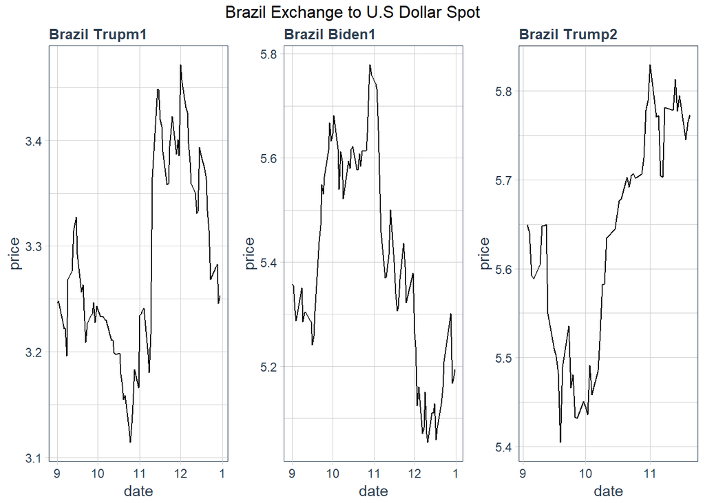

```r
brazil_exchange <- grid.arrange(
  p_brazil_2016, p_brazil_2020, p_brazil_2024,
  ncol = 3, top = "Brazil Exchange to U.S Dollar Spot")
```

## Figure 7: BICS Exchange Rate Comparison

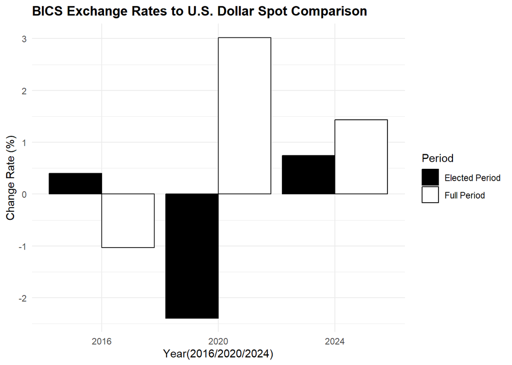

```r
# Combine all datasets into one with a country label
data_combined <- bind_rows(
  brazil %>% mutate(country = "Brazil"),
  india %>% mutate(country = "India"),
  china %>% mutate(country = "China"),
  south_africa %>% mutate(country = "South Africa")
)

# Calculate average price for BRICS for specific periods
calculate_brics_rate <- function(data, start_date, end_date) {
  period_data <- data %>% filter(date >= as.Date(start_date) & date <= as.Date(end_date))
  avg_rate <- period_data %>% group_by(date) %>% summarise(avg_price = mean(price, na.rm = TRUE))
  change_rate <- (last(avg_rate$avg_price) - first(avg_rate$avg_price)) / first(avg_rate$avg_price) * 100
  return(change_rate)
}

# Calculate change rates for elected periods and full periods
elected_2016 <- calculate_brics_rate(data_combined, '2016-09-01', '2016-12-31')
full_2016 <- calculate_brics_rate(data_combined, '2016-01-01', '2016-12-31')

elected_2020 <- calculate_brics_rate(data_combined, '2020-09-01', '2020-12-31')
full_2020 <- calculate_brics_rate(data_combined, '2020-01-01', '2020-12-31')

elected_2024 <- calculate_brics_rate(data_combined, '2024-09-01', '2024-11-20')
full_2024 <- calculate_brics_rate(data_combined, '2024-01-01', '2024-11-20')

# Create a data frame for visualization
rate_data <- data.frame(
  Period = c("Elected Period", "Full Period", "Elected Period", "Full Period", "Elected Period", "Full Period"),
  Year = c("2016", "2016", "2020", "2020", "2024", "2024"),
  ChangeRate = c(elected_2016, full_2016, elected_2020, full_2020, elected_2024, full_2024)
)

# Plot the change rates
plot6 <- ggplot(rate_data, aes(x = Year, y = ChangeRate, fill = Period)) +
  geom_bar(stat = "identity", position = "dodge", color = "black") +
  scale_fill_manual(values = c("black", "white")) +
  theme_minimal() +
  theme(plot.title = element_text(face = "bold")) +
  labs(
    title = "BICS Exchange Rates to U.S. Dollar Spot Comparison",
    x = "Year(2016/2020/2024)",
    y = "Change Rate (%)",
    fill = "Period"
  )

# Display the plot
plot6
```

## Figure 8: BIC Stock Market Trends

Since I could not find a representative stock index for South Africa, I focused on the indices for Brazil, India, and China (Shanghai). Similar to exchange rate fluctuations, these indices showed sharp changes during November, coinciding with U.S. election periods.

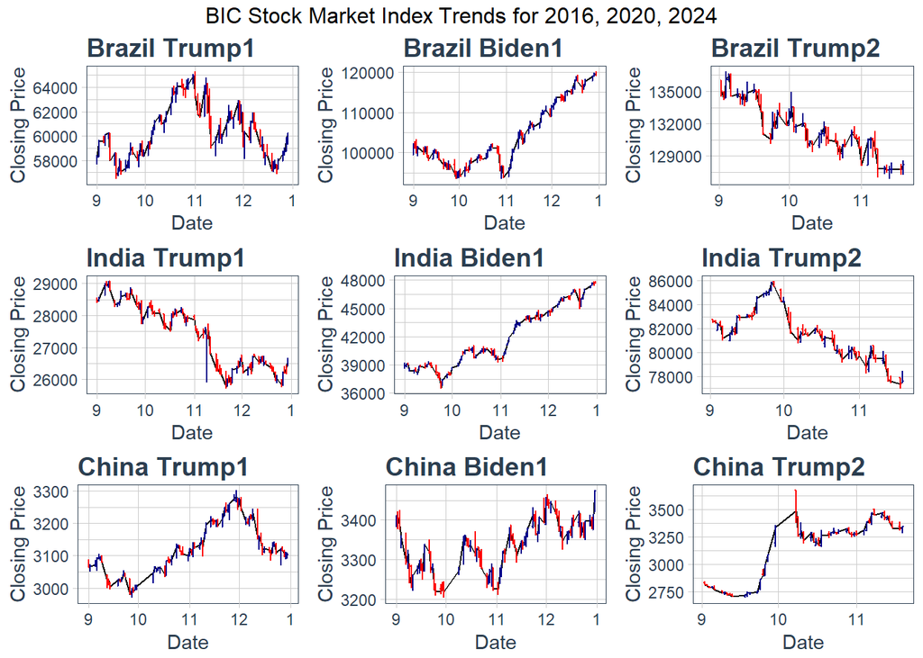

```r
library(tidyquant)
library(ggplot2)

# Get stock market data for the selected countries
brazil_index <- tq_get('^BVSP', get = 'stock.prices', from = '2016-01-01', to = '2024-11-20')
india_index <- tq_get('^BSESN', get = 'stock.prices', from = '2016-01-01', to = '2024-11-20')
china_index <- tq_get('000001.SS', get = 'stock.prices', from = '2016-01-01', to = '2024-11-20')

# Ensure the date column is in Date format for all datasets and remove missing values
brazil_index <- brazil_index %>% mutate(date = as.Date(date)) %>% drop_na()
india_index <- india_index %>% mutate(date = as.Date(date)) %>% drop_na()
china_index <- china_index %>% mutate(date = as.Date(date)) %>% drop_na()

# Filter the data for specific periods for each country
filter_periods <- function(data, start_date, end_date) {
  data %>% filter(date >= as.Date(start_date) & date <= as.Date(end_date))
}

# Create filtered data for each country and period
brazil_2016 <- filter_periods(brazil_index, '2016-09-01', '2016-12-31')
brazil_2020 <- filter_periods(brazil_index, '2020-09-01', '2020-12-31')
brazil_2024 <- filter_periods(brazil_index, '2024-09-01', '2024-11-20')

india_2016 <- filter_periods(india_index, '2016-09-01', '2016-12-31')
india_2020 <- filter_periods(india_index, '2020-09-01', '2020-12-31')
india_2024 <- filter_periods(india_index, '2024-09-01', '2024-11-20')

china_2016 <- filter_periods(china_index, '2016-09-01', '2016-12-31')
china_2020 <- filter_periods(china_index, '2020-09-01', '2020-12-31')
china_2024 <- filter_periods(china_index, '2024-09-01', '2024-11-20')

# Plot for each country and period
create_plot <- function(data, title) {
  ggplot(data, aes(x = date, y = close)) +
    geom_line() +
    geom_barchart(aes(open = open, high = high, low = low, close = close)) +
    theme_tq() +
    labs(title = title, x = "Date", y = "Closing Price") +
    theme(plot.title = element_text(size = 14, face = "bold"),
          plot.margin = margin(3, 5, 3, 5))
}

# Generate plots for Brazil
p_brazil_2016 <- create_plot(brazil_2016, "Brazil Trump1")
p_brazil_2020 <- create_plot(brazil_2020, "Brazil Biden1")
p_brazil_2024 <- create_plot(brazil_2024, "Brazil Trump2")

# Generate plots for India
p_india_2016 <- create_plot(india_2016, "India Trump1")
p_india_2020 <- create_plot(india_2020, "India Biden1")
p_india_2024 <- create_plot(india_2024, "India Trump2")

# Generate plots for China
p_china_2016 <- create_plot(china_2016, "China Trump1")
p_china_2020 <- create_plot(china_2020, "China Biden1")
p_china_2024 <- create_plot(china_2024, "China Trump2")

# Display all plots in a grid
library(gridExtra)
plot7 <- grid.arrange(
  p_brazil_2016, p_brazil_2020, p_brazil_2024,
  p_india_2016, p_india_2020, p_india_2024,
  p_china_2016, p_china_2020, p_china_2024,
  ncol = 3, top = "BIC Stock Market Index Trends for 2016, 2020, 2024")
```

## Figure 9: Brazil Stock Market Trends

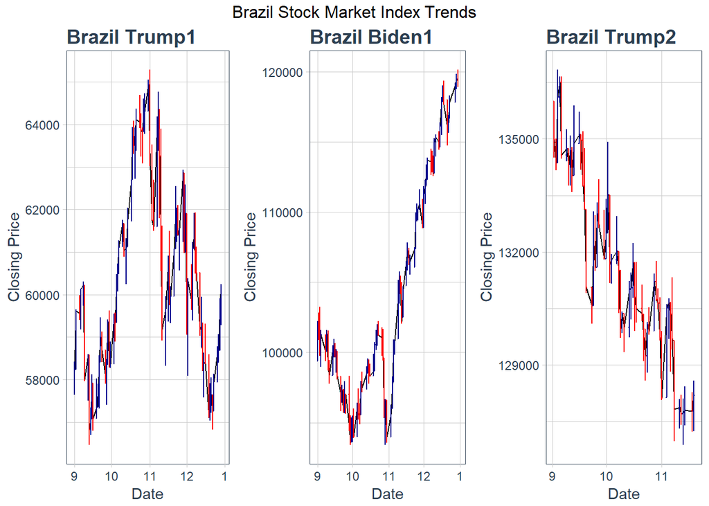

```r
plot_brazil_index <- grid.arrange(
  p_brazil_2016, p_brazil_2020, p_brazil_2024,
  ncol = 3, top = "Brazil Stock Market Index Trends")
```

## Figure 10: BIC Stock Market Change Rate Comparison

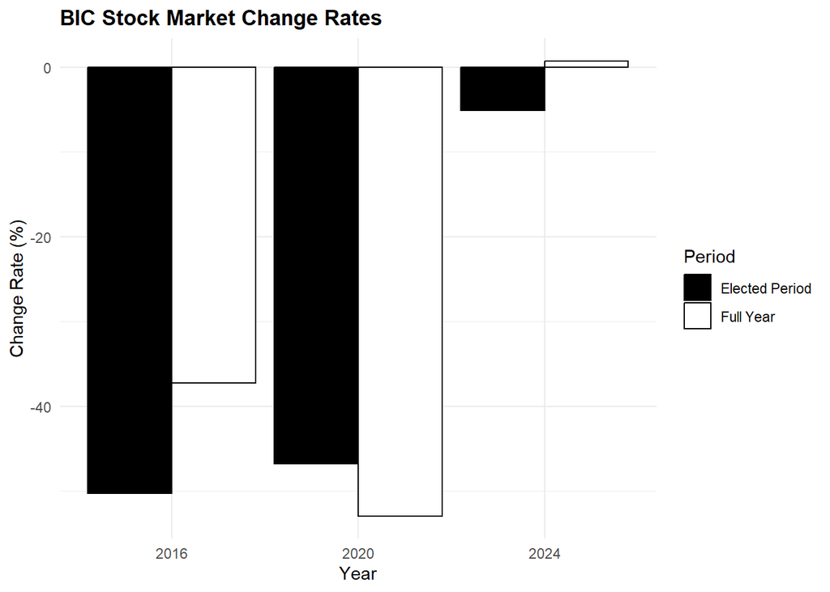

```r
# Combine data into a single BRICS dataset
combined_data <- bind_rows(
  brazil_index %>% mutate(country = "Brazil"),
  india_index %>% mutate(country = "India"),
  china_index %>% mutate(country = "China")
)

# Calculate average change rate for BRICS
calculate_brics_change_rate <- function(data, start_date, end_date) {
  period_data <- data %>% filter(date >= as.Date(start_date) & date <= as.Date(end_date))
  avg_close <- period_data %>% group_by(date) %>% summarise(avg_close = mean(close, na.rm = TRUE))
  change_rate <- (last(avg_close$avg_close) - first(avg_close$avg_close)) / first(avg_close$avg_close) * 100
  return(change_rate)
}

# Calculate change rates for elected periods and full periods
elected_2016 <- calculate_brics_change_rate(combined_data, '2016-09-01', '2016-12-31')
full_2016 <- calculate_brics_change_rate(combined_data, '2016-01-01', '2016-12-31')

elected_2020 <- calculate_brics_change_rate(combined_data, '2020-09-01', '2020-12-31')
full_2020 <- calculate_brics_change_rate(combined_data, '2020-01-01', '2020-12-31')

elected_2024 <- calculate_brics_change_rate(combined_data, '2024-09-01', '2024-11-20')
full_2024 <- calculate_brics_change_rate(combined_data, '2024-01-01', '2024-11-20')

# Create a data frame for visualization
rate_data <- data.frame(
  Period = c("Elected Period", "Full Year", "Elected Period", "Full Year", "Elected Period", "Full Year"),
  Year = c("2016", "2016", "2020", "2020", "2024", "2024"),
  ChangeRate = c(elected_2016, full_2016, elected_2020, full_2020, elected_2024, full_2024)
)

# Plot the change rates
plot2 <- ggplot(rate_data, aes(x = Year, y = ChangeRate, fill = Period)) +
  geom_bar(stat = "identity", position = "dodge", color = "black") +
  scale_fill_manual(values = c("Black", "White")) +
  theme_minimal() +
  theme(plot.title = element_text(face = "bold")) +
  labs(
    title = "BIC Stock Market Change Rates",
    x = "Year",
    y = "Change Rate (%)",
    fill = "Period"
  )

# Display the plot
plot2
```

## Figure 11: Impact of Trump’s 2016 Election on South Korea’s Major Industries

This figure explores the effects of Trump’s 2016 election on South Korea’s key industries by analyzing the average stock price changes before and after the election. The first chart highlights the average change rates for all industries during the pre-election and post-election periods, illustrating the differing impacts of Trump’s unexpected victory across sectors. The second chart focuses on the top 5 industries with the largest changes between these periods, showcasing sectors such as transportation equipment, mining, and pharmaceuticals, which experienced significant volatility. These results reflect the market’s response to Trump’s policy agenda, including trade protectionism and energy deregulation, underscoring the sensitivity of South Korea’s export-driven industries to U.S. political shifts.

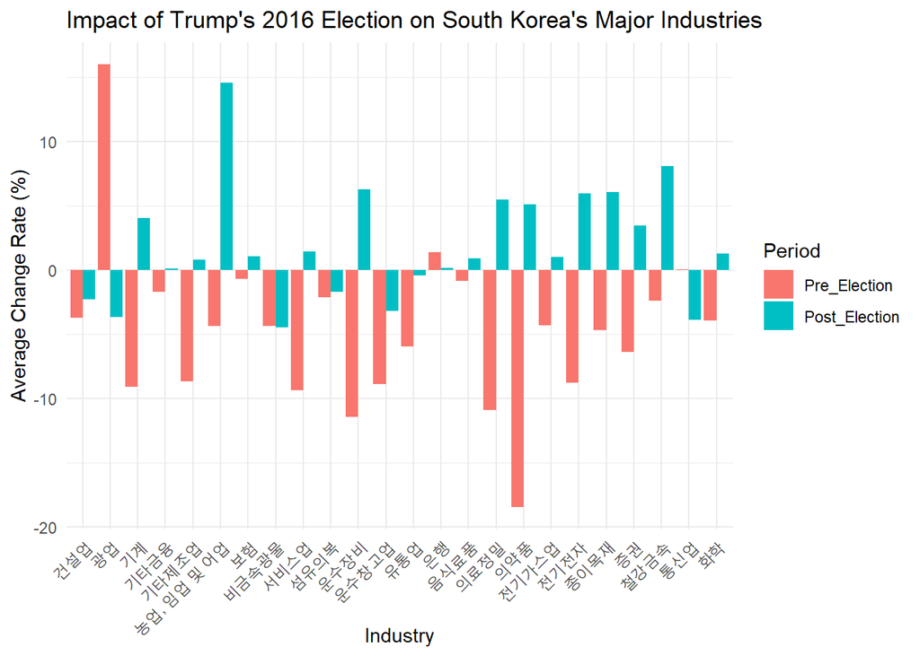

```r
library(dplyr)
library(lubridate)
library(readxl)
library(ggplot2)

file_1_path <- "2016_industry classification.xlsx"
file_2_path <- "2016_Post_Election.xlsx"
file_3_path <- "2016_Pre_Election.xlsx"

file_1_df <- read_excel(file_1_path, sheet = 'Sheet1')
file_2_df <- read_excel(file_2_path, sheet = 'Sheet1')
file_3_df <- read_excel(file_3_path, sheet = 'Sheet1')

# Add a period indicator to differentiate between pre-election and post-election data
file_2_df <- file_2_df %>% mutate(Period = 'Post_Election')
file_3_df <- file_3_df %>% mutate(Period = 'Pre_Election')

# Merge File 1 with File 2 and File 3 to include 업종명(Industry) in the combined dataframe
file_2_merged <- left_join(file_2_df, file_1_df %>% select(종목코드, 업종명), by = '종목코드')
file_3_merged <- left_join(file_3_df, file_1_df %>% select(종목코드, 업종명), by = '종목코드')

# Concatenate the merged dataframes
combined_df_with_industry <- bind_rows(file_2_merged, file_3_merged)  #

# Group by 업종명 (Industry) and Period, calculate the mean 등락률 (Change Rate)
grouped_change_rate_with_industry <- combined_df_with_industry %>%
  group_by(업종명, Period) %>%
  summarise(mean_change_rate = mean(등락률, na.rm = TRUE), .groups = "drop") %>%
  ungroup()

# Plot the results using ggplot2
ggplot(grouped_change_rate_with_industry, aes(x = 업종명, y = mean_change_rate, fill = factor(Period, levels = c('Pre_Election', 'Post_Election')))) +
  geom_bar(stat = 'identity', position = position_dodge()) +
  labs(title = "Impact of Trump's 2016 Election on South Korea's Major Industries",
       x = 'Industry',
       y = 'Average Change Rate (%)',
       fill = 'Period') +
  theme_minimal() +
  theme(axis.text.x = element_text(angle = 45, hjust = 1))
```

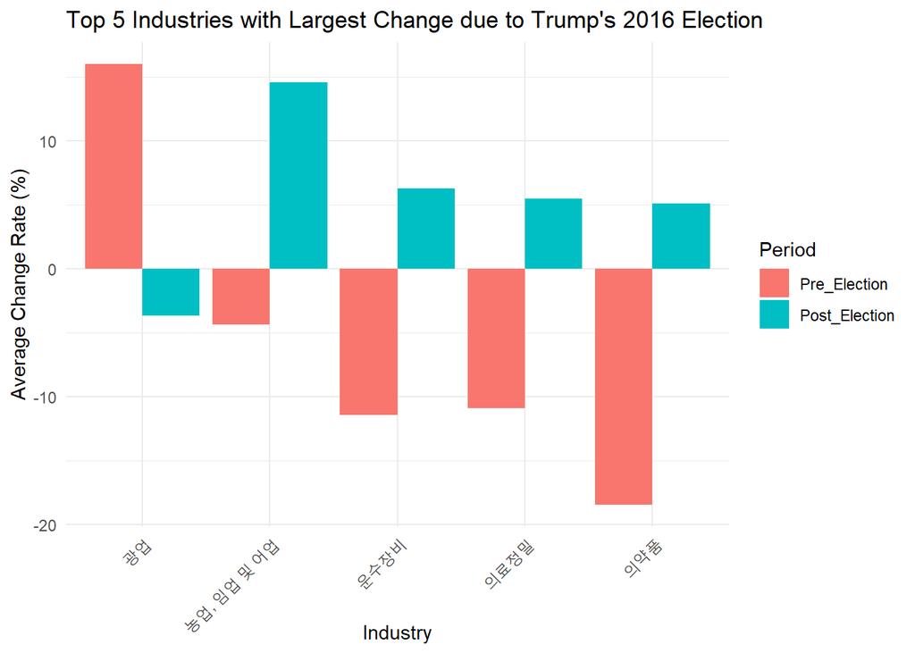

```r
# Calculate the top 5 industries with the largest change between pre and post-election
top_5_industries <- grouped_change_rate_with_industry %>%
  tidyr::spread(key = Period, value = mean_change_rate) %>%
  mutate(change_diff = abs(Post_Election - Pre_Election)) %>%
  arrange(desc(change_diff)) %>%
  top_n(5, wt = change_diff) %>%
  tidyr::gather(key = "Period", value = "mean_change_rate", Pre_Election, Post_Election)

# Plot the top 5 industries with the largest change
ggplot(top_5_industries, aes(x = 업종명, y = mean_change_rate, fill = factor(Period, levels = c('Pre_Election', 'Post_Election')))) +
  geom_bar(stat = 'identity', position = position_dodge()) +
  labs(title = "Top 5 Industries with Largest Change due to Trump's 2016 Election",
       x = 'Industry',
       y = 'Average Change Rate (%)',
       fill = 'Period') +
  theme_minimal() +
  theme(axis.text.x = element_text(angle = 45, hjust = 1))
```

## Figure 12: Impact of Biden’s 2020 Election on South Korea’s Major Industries

This figure examines the impact of Biden’s 2020 election on South Korea’s key industries by analyzing the average stock price changes before and after the election. The analysis highlights how industries responded differently to the transition in U.S. leadership. A bar chart shows the average change rates for all industries during the pre-election and post-election periods, emphasizing shifts influenced by Biden’s pro-environmental policies, infrastructure investments, and trade stabilization efforts. Additionally, a focused analysis identifies the top 5 industries with the largest change in average stock performance, showcasing industries like construction and transportation equipment that benefitted from Biden’s infrastructure and clean energy agenda. This visualization underscores the significant impact of U.S. policy shifts on global markets, particularly South Korea’s export-driven economy.

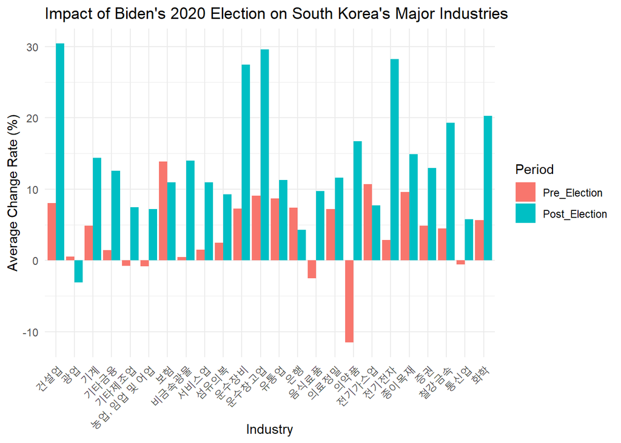

```r
# Load the data from the Excel files for Biden 2020 analysis
biden_file_1_path <- "2020_Pre_Election.xlsx"
biden_file_2_path <- "2020_Post_Election.xlsx"
biden_file_3_path <- "2020_industry classification.xlsx"

# Read the data from the sheets
biden_file_1_df <- read_excel(biden_file_1_path, sheet = 'Sheet1')
biden_file_2_df <- read_excel(biden_file_2_path, sheet = 'Sheet1')
biden_file_3_df <- read_excel(biden_file_3_path, sheet = 'Sheet1')

# Add a period indicator to differentiate between pre-election and post-election data
biden_file_1_df <- biden_file_1_df %>% mutate(Period = 'Pre_Election')
biden_file_2_df <- biden_file_2_df %>% mutate(Period = 'Post_Election')

# Merge File 1 and File 2 with File 3 to include 업종명(Industry) in the combined dataframe
biden_file_1_merged <- left_join(biden_file_1_df, biden_file_3_df %>% select(종목코드, 업종명), by = '종목코드')
biden_file_2_merged <- left_join(biden_file_2_df, biden_file_3_df %>% select(종목코드, 업종명), by = '종목코드')

# Concatenate the merged dataframes
biden_combined_df_with_industry <- bind_rows(biden_file_1_merged, biden_file_2_merged)

# Group by 업종명 (Industry) and Period, calculate the mean 등락률 (Change Rate)
grouped_change_rate_with_industry_biden <- biden_combined_df_with_industry %>%
  group_by(업종명, Period) %>%
  summarise(mean_change_rate = mean(등락률, na.rm = TRUE), .groups = "drop") %>%
  ungroup()

# Plot the results using ggplot2
ggplot(grouped_change_rate_with_industry_biden, aes(x = 업종명, y = mean_change_rate, fill = factor(Period, levels = c('Pre_Election', 'Post_Election')))) +
  geom_bar(stat = 'identity', position = position_dodge()) +
  labs(title = "Impact of Biden's 2020 Election on South Korea's Major Industries",
       x = 'Industry',
       y = 'Average Change Rate (%)',
       fill = 'Period') +
  theme_minimal() +
  theme(axis.text.x = element_text(angle = 45, hjust = 1))
```

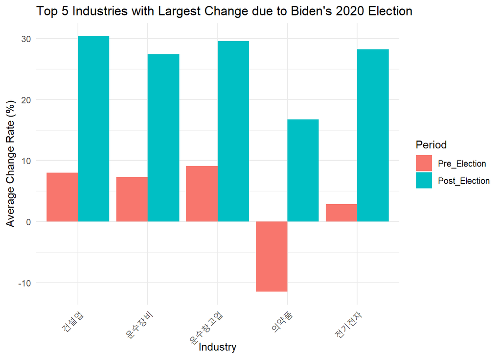

```r
# Calculate the top 5 industries with the largest change between pre and post-election
top_5_industries_biden <- grouped_change_rate_with_industry_biden %>%
  tidyr::spread(key = Period, value = mean_change_rate) %>%
  mutate(change_diff = abs(Post_Election - Pre_Election)) %>%
  arrange(desc(change_diff)) %>%
  top_n(5, wt = change_diff) %>%
  tidyr::gather(key = "Period", value = "mean_change_rate", Pre_Election, Post_Election)

# Plot the top 5 industries with the largest change
ggplot(top_5_industries_biden, aes(x = 업종명, y = mean_change_rate, fill = factor(Period, levels = c('Pre_Election', 'Post_Election')))) +
  geom_bar(stat = 'identity', position = position_dodge()) +
  labs(title = "Top 5 Industries with Largest Change due to Biden's 2020 Election",
       x = 'Industry',
       y = 'Average Change Rate (%)',
       fill = 'Period') +
  theme_minimal() +
  theme(axis.text.x = element_text(angle = 45, hjust = 1))
```

## conclusion:

Biden’s pledge to expand investment in eco-friendly energy, infrastructure has had a positive impact on construction, electric and electronics, and transportation equipment. The pharmaceutical industry recorded big gains on pandemic response policies and support for vaccine development. The transportation warehouse industry rose on expectations of stabilizing the international logistics network.

## Figure 13: Anticipated Impact of Trump’s 2024 Election on South Korea’s Major Industries

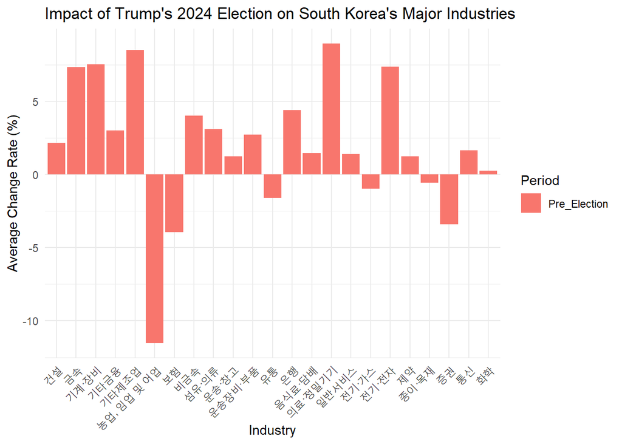

```r
# Load the data from the Excel files for Trump 2nd Term 2024 analysis
trump_file_1_path <- "2024_industry classification.xlsx"
trump_file_2_path <- "2024_Pre_Election.xlsx"

# Read the data from the sheets
trump_file_1_df <- read_excel(trump_file_1_path, sheet = 'Sheet1')
trump_file_2_df <- read_excel(trump_file_2_path, sheet = 'Sheet1')

# Add a period indicator to differentiate pre-election data
trump_file_2_df <- trump_file_2_df %>% mutate(Period = 'Pre_Election')

# Merge File 2 with File 1 to include 업종명(Industry) in the dataframe
trump_file_2_merged <- left_join(trump_file_2_df, trump_file_1_df %>% select(종목코드, 업종명), by = '종목코드')

# Group by 업종명(Industry), calculate the mean 등락률 (Change Rate)
grouped_change_rate_with_industry_trump <- trump_file_2_merged %>%
  group_by(업종명, Period) %>%
  summarise(mean_change_rate = mean(등락률, na.rm = TRUE), .groups = "drop") %>%
  ungroup()

# Plot the results using ggplot2
ggplot(grouped_change_rate_with_industry_trump, aes(x = 업종명, y = mean_change_rate, fill = Period)) +
  geom_bar(stat = 'identity', position = position_dodge()) +
  labs(title = "Impact of Trump's 2024 Election on South Korea's Major Industries",
       x = 'Industry',
       y = 'Average Change Rate (%)',
       fill = 'Period') +
  theme_minimal() +
  theme(axis.text.x = element_text(angle = 45, hjust = 1))
```

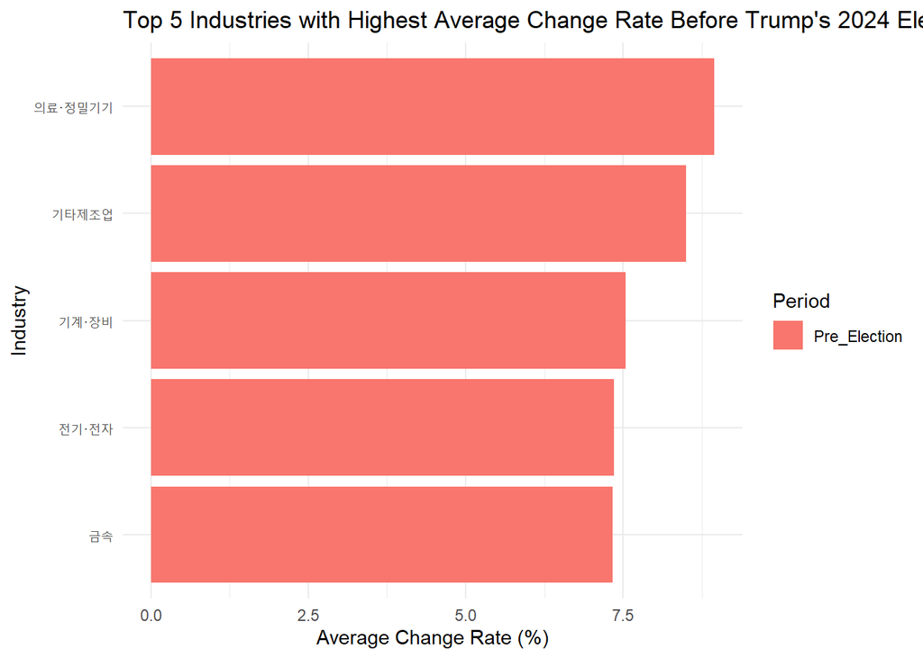

```r
# Find the top 5 industries with the highest pre-election average rate
top_5_industries_trump <- grouped_change_rate_with_industry_trump %>%
  arrange(desc(mean_change_rate)) %>%
  top_n(5, wt = mean_change_rate)

# Plot the top 5 industries with the highest pre-election average rate
ggplot(top_5_industries_trump, aes(x = reorder(업종명, mean_change_rate), y = mean_change_rate, fill = Period)) +
  geom_bar(stat = 'identity') +
  coord_flip() +
  labs(title = "Top 5 Industries with Highest Average Change Rate Before Trump's 2024 Election",
       x = 'Industry',
       y = 'Average Change Rate (%)',
       fill = 'Period') +
  theme_minimal()
```

## conclusion:

Positive Impact: Expansion of infrastructure investment and concentration in the technology industry will provide opportunities for Korea’s construction, electrical and electronic, and transportation equipment industries. In particular, strengthening investment in semiconductors and high-tech in the United States has the potential to highlight the competitiveness of Korean companies.

Negative Impact: Increased protection trade could leave automobiles and manufacturers struggling with tougher tariffs and regulations. International logistics-related industries, such as transport warehousing, may be affected by increased global costs and a new regulatory environment.